# PART A: Box Plots

### 12. Density

#### Scatter Plot

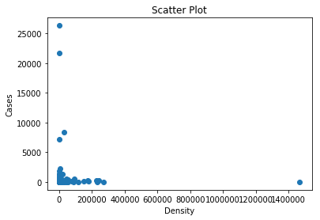

```python
#Provide convenient legend.
plt.scatter(df['cases'], df['Density'])
plt.title('Scatter Plot')
plt.xlabel('Density')
plt.ylabel('Cases')
plt.show()
```

#### Regression Model

```python
result = smf.ols('cases ~ Density', data = df).fit()

# Inspect the results
print(result.summary())
```

```
                            OLS Regression Results
==============================================================================
Dep. Variable:                  cases   R-squared:                       0.001
Model:                            OLS   Adj. R-squared:                 -0.004
Method:                 Least Squares   F-statistic:                    0.1474
Date:                Wed, 03 Jun 2020   Prob (F-statistic):              0.701
Time:                        20:21:27   Log-Likelihood:                -2507.6
No. Observations:                 192   AIC:                             5019.
Df Residuals:                     190   BIC:                             5026.
Df Model:                           1
Covariance Type:            nonrobust
==============================================================================
                 coef    std err          t      P>|t|      [0.025      0.975]
------------------------------------------------------------------------------
Intercept   2.473e+04   8409.045      2.941      0.004    8145.475    4.13e+04
Density       -1.2387      3.226     -0.384      0.701      -7.602       5.125
==============================================================================
Omnibus:                      377.523   Durbin-Watson:                   2.063
Prob(Omnibus):                  0.000   Jarque-Bera (JB):           144078.115
Skew:                          10.854   Prob(JB):                         0.00
Kurtosis:                     135.433   Cond. No.                     2.66e+03
==============================================================================

Warnings:
[1] Standard Errors assume that the covariance matrix of the errors is correctly specified.
[2] The condition number is large, 2.66e+03. This might indicate that there are
strong multicollinearity or other numerical problems.
```

The regression equation is $y = 2.473e+04 - 1.2387x$ .

#### Check for normaloty assumption

#### 1. Histogram

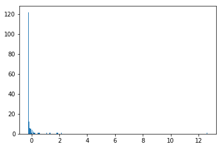

```python
_ = plt.hist(result.resid_pearson, bins = 'auto')
```

#### 2. QQ Plot

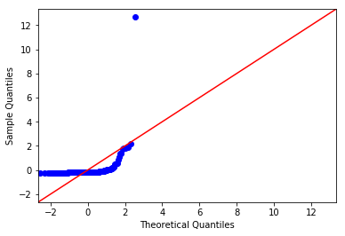

```python
fig = sm.qqplot(result.resid_pearson, stats.norm, fit=True, line='45')
```

#### 3. Shapiro Test

$H_0$ : Standardized residuals are normally distributed.  
$H_1$ : Standardized residuals are not normally distributed

```python
stat, p = stats.shapiro(result.resid_pearson)
print('Statistics=%.3f, p=%.3f' % (stat, p))
```

```
Statistics=0.190, p=0.000
```

The p value is smaller than the significant level , we can reject $H_0$ , that means the normality assumption is not satisfied.

#### Regression Model (Use log value)

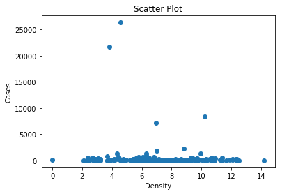

```python
#Provide convenient legend.
plt.scatter(df['case_log'], df['Density'])
plt.title('Scatter Plot')
plt.xlabel('Density')
plt.ylabel('Cases')
plt.show()
```

```python
result = smf.ols('case_log ~ Density', data = df).fit()

# Inspect the results
print(result.summary())
```

```
                            OLS Regression Results
==============================================================================
Dep. Variable:               case_log   R-squared:                       0.007
Model:                            OLS   Adj. R-squared:                  0.002
Method:                 Least Squares   F-statistic:                     1.362
Date:                Wed, 03 Jun 2020   Prob (F-statistic):              0.245
Time:                        20:21:28   Log-Likelihood:                -461.56
No. Observations:                 192   AIC:                             927.1
Df Residuals:                     190   BIC:                             933.6
Df Model:                           1
Covariance Type:            nonrobust
==============================================================================
                 coef    std err          t      P>|t|      [0.025      0.975]
------------------------------------------------------------------------------
Intercept      7.1341      0.198     36.030      0.000       6.744       7.525
Density    -8.865e-05    7.6e-05     -1.167      0.245      -0.000    6.12e-05
==============================================================================
Omnibus:                        2.869   Durbin-Watson:                   1.517
Prob(Omnibus):                  0.238   Jarque-Bera (JB):                2.014
Skew:                           0.013   Prob(JB):                        0.365
Kurtosis:                       2.499   Cond. No.                     2.66e+03
==============================================================================

Warnings:
[1] Standard Errors assume that the covariance matrix of the errors is correctly specified.
[2] The condition number is large, 2.66e+03. This might indicate that there are
strong multicollinearity or other numerical problems.
```

#### Check for normaloty assumption

#### 1. Histogram

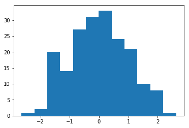

```python
_ = plt.hist(result.resid_pearson, bins = 'auto')
```

#### 2. QQ Plot

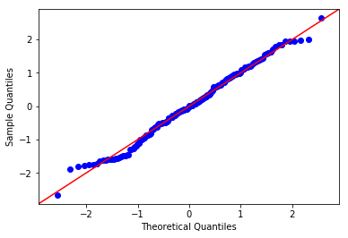

```python
fig = sm.qqplot(result.resid_pearson, stats.norm, fit=True, line='45')
```

#### 3. Shapiro Test

$H_0$ : Standardized residuals are normally distributed.  
$H_1$ : Standardized residuals are not normally distributed

```python
stat, p = stats.shapiro(result.resid_pearson)
print('Statistics=%.3f, p=%.3f' % (stat, p))
```

```
Statistics=0.990, p=0.203
```

The p value is larger than the significant level , we can't reject $H_0$ , that means the normality assumption is satisfied.

### 13. Med age

#### Scatter Plot

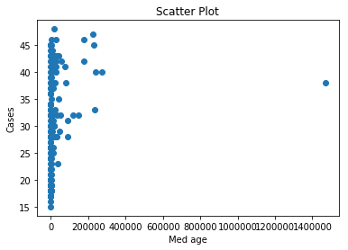

```python
#Provide convenient legend.
plt.scatter(df['cases'], df['Med_age'])
plt.title('Scatter Plot')
plt.xlabel('Med age')
plt.ylabel('Cases')
plt.show()
```

#### Regression Model

```python
result = smf.ols('cases ~ Med_age', data = df).fit()

# Inspect the results
print(result.summary())
```

```
                            OLS Regression Results
==============================================================================
Dep. Variable:                  cases   R-squared:                       0.031
Model:                            OLS   Adj. R-squared:                  0.026
Method:                 Least Squares   F-statistic:                     5.817
Date:                Wed, 03 Jun 2020   Prob (F-statistic):             0.0169
Time:                        20:21:29   Log-Likelihood:                -2366.2
No. Observations:                 181   AIC:                             4736.
Df Residuals:                     179   BIC:                             4743.
Df Model:                           1
Covariance Type:            nonrobust
==============================================================================
                 coef    std err          t      P>|t|      [0.025      0.975]
------------------------------------------------------------------------------
Intercept  -4.445e+04   3.03e+04     -1.468      0.144   -1.04e+05    1.53e+04
Med_age     2289.1737    949.168      2.412      0.017     416.175    4162.173
==============================================================================
Omnibus:                      355.463   Durbin-Watson:                   2.084
Prob(Omnibus):                  0.000   Jarque-Bera (JB):           124787.642
Skew:                          10.610   Prob(JB):                         0.00
Kurtosis:                     129.871   Cond. No.                         112.
==============================================================================

Warnings:
[1] Standard Errors assume that the covariance matrix of the errors is correctly specified.
```

The regression equation is $y = -4.445e+04 + 2289.1737x$ .

#### Check for normaloty assumption

#### 1. Histogram

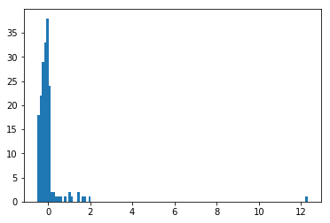

```python
_ = plt.hist(result.resid_pearson, bins = 'auto')
```

#### 2. QQ Plot

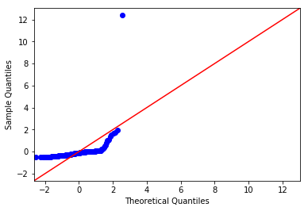

```python
fig = sm.qqplot(result.resid_pearson, stats.norm, fit=True, line='45')
```

#### 3. Shapiro Test

$H_0$ : Standardized residuals are normally distributed.  
$H_1$ : Standardized residuals are not normally distributed

```python
stat, p = stats.shapiro(result.resid_pearson)
print('Statistics=%.3f, p=%.3f' % (stat, p))
```

```
Statistics=0.259, p=0.000
```

The p value is smaller than the significant level , we can reject $H_0$ , that means the normality assumption is not satisfied.

#### Regression Model (Use log value)

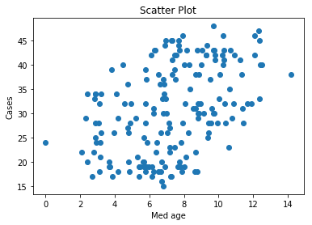

```python
#Provide convenient legend.
plt.scatter(df['case_log'], df['Med_age'])
plt.title('Scatter Plot')
plt.xlabel('Med age')
plt.ylabel('Cases')
plt.show()
```

```python
result = smf.ols('case_log ~ Med_age', data = df).fit()

# Inspect the results
print(result.summary())
```

```
                            OLS Regression Results
==============================================================================
Dep. Variable:               case_log   R-squared:                       0.196
Model:                            OLS   Adj. R-squared:                  0.192
Method:                 Least Squares   F-statistic:                     43.68
Date:                Wed, 03 Jun 2020   Prob (F-statistic):           4.29e-10
Time:                        20:21:29   Log-Likelihood:                -413.84
No. Observations:                 181   AIC:                             831.7
Df Residuals:                     179   BIC:                             838.1
Df Model:                           1
Covariance Type:            nonrobust
==============================================================================
                 coef    std err          t      P>|t|      [0.025      0.975]
------------------------------------------------------------------------------
Intercept      3.2910      0.626      5.257      0.000       2.056       4.526
Med_age        0.1297      0.020      6.609      0.000       0.091       0.168
==============================================================================
Omnibus:                        2.944   Durbin-Watson:                   1.801
Prob(Omnibus):                  0.229   Jarque-Bera (JB):                2.515
Skew:                          -0.184   Prob(JB):                        0.284
Kurtosis:                       2.555   Cond. No.                         112.
==============================================================================

Warnings:
[1] Standard Errors assume that the covariance matrix of the errors is correctly specified.
```

#### Check for normaloty assumption

#### 1. Histogram

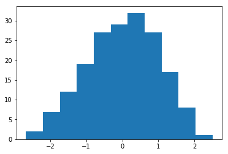

```python
_ = plt.hist(result.resid_pearson, bins = 'auto')
```

#### 2. QQ Plot

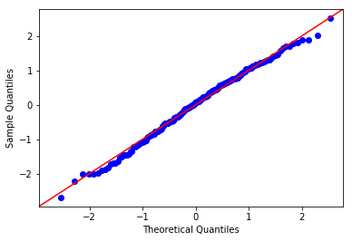

```python
fig = sm.qqplot(result.resid_pearson, stats.norm, fit=True, line='45')
```

#### 3. Shapiro Test

$H_0$ : Standardized residuals are normally distributed.  
$H_1$ : Standardized residuals are not normally distributed

```python
stat, p = stats.shapiro(result.resid_pearson)
print('Statistics=%.3f, p=%.3f' % (stat, p))
```

```
Statistics=0.993, p=0.483
```

The p value is larger than the significant level , we can't reject $H_0$ , that means the normality assumption is satisfied.

### 14. Urban pop proportion

#### Scatter Plot

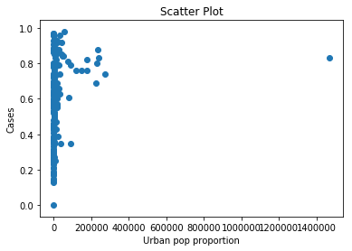

```python
#Provide convenient legend.
plt.scatter(df['cases'], df['Urban_pop_proportion'])
plt.title('Scatter Plot')
plt.xlabel('Urban pop proportion')
plt.ylabel('Cases')
plt.show()
```

#### Regression Model

```python
result = smf.ols('cases ~ Urban_pop_proportion', data = df).fit()

# Inspect the results
print(result.summary())
```

```
                            OLS Regression Results
==============================================================================
Dep. Variable:                  cases   R-squared:                       0.029
Model:                            OLS   Adj. R-squared:                  0.024
Method:                 Least Squares   F-statistic:                     5.478
Date:                Wed, 03 Jun 2020   Prob (F-statistic):             0.0203
Time:                        20:21:30   Log-Likelihood:                -2429.5
No. Observations:                 186   AIC:                             4863.
Df Residuals:                     184   BIC:                             4869.
Df Model:                           1
Covariance Type:            nonrobust
========================================================================================
                           coef    std err          t      P>|t|      [0.025      0.975]
----------------------------------------------------------------------------------------
Intercept            -2.762e+04   2.39e+04     -1.158      0.249   -7.47e+04    1.95e+04
Urban_pop_proportion  8.753e+04   3.74e+04      2.341      0.020    1.37e+04    1.61e+05
==============================================================================
Omnibus:                      364.261   Durbin-Watson:                   2.084
Prob(Omnibus):                  0.000   Jarque-Bera (JB):           131324.405
Skew:                          10.652   Prob(JB):                         0.00
Kurtosis:                     131.418   Cond. No.                         6.11
==============================================================================

Warnings:
[1] Standard Errors assume that the covariance matrix of the errors is correctly specified.
```

The regression equation is $y = -2.762e+04 + (8.753e+04)x$ .

#### Check for normaloty assumption

#### 1. Histogram

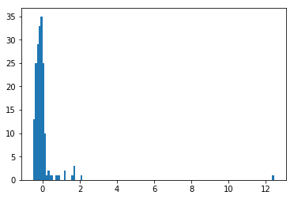

```python
_ = plt.hist(result.resid_pearson, bins = 'auto')
```

#### 2. QQ Plot

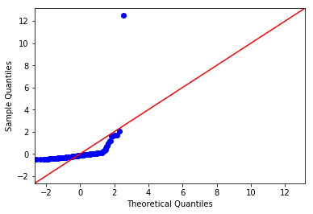

```python
fig = sm.qqplot(result.resid_pearson, stats.norm, fit=True, line='45')
```

#### 3. Shapiro Test

$H_0$ : Standardized residuals are normally distributed.  
$H_1$ : Standardized residuals are not normally distributed

```python
stat, p = stats.shapiro(result.resid_pearson)
print('Statistics=%.3f, p=%.3f' % (stat, p))
```

```
Statistics=0.256, p=0.000
```

The p value is smaller than the significant level , we can reject $H_0$ , that means the normality assumption is not satisfied.

#### Regression Model (Use log value)

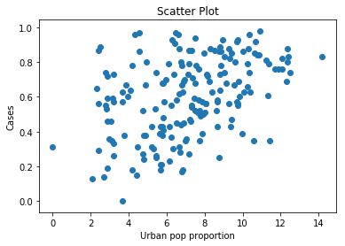

```python
#Provide convenient legend.
plt.scatter(df['case_log'], df['Urban_pop_proportion'])
plt.title('Scatter Plot')
plt.xlabel('Urban pop proportion')
plt.ylabel('Cases')
plt.show()
```

```python
result = smf.ols('case_log ~ Urban_pop_proportion', data = df).fit()

# Inspect the results
print(result.summary())
```

```
                            OLS Regression Results
==============================================================================
Dep. Variable:               case_log   R-squared:                       0.175
Model:                            OLS   Adj. R-squared:                  0.170
Method:                 Least Squares   F-statistic:                     38.94
Date:                Wed, 03 Jun 2020   Prob (F-statistic):           2.94e-09
Time:                        20:21:30   Log-Likelihood:                -430.62
No. Observations:                 186   AIC:                             865.2
Df Residuals:                     184   BIC:                             871.7
Df Model:                           1
Covariance Type:            nonrobust
========================================================================================
                           coef    std err          t      P>|t|      [0.025      0.975]
----------------------------------------------------------------------------------------
Intercept                4.0967      0.513      7.978      0.000       3.084       5.110
Urban_pop_proportion     5.0219      0.805      6.240      0.000       3.434       6.610
==============================================================================
Omnibus:                        1.911   Durbin-Watson:                   1.607
Prob(Omnibus):                  0.385   Jarque-Bera (JB):                1.965
Skew:                          -0.207   Prob(JB):                        0.374
Kurtosis:                       2.714   Cond. No.                         6.11
==============================================================================

Warnings:
[1] Standard Errors assume that the covariance matrix of the errors is correctly specified.
```

#### Check for normaloty assumption

#### 1. Histogram

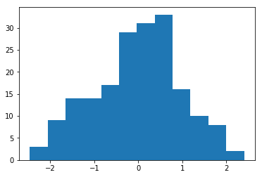

```python
_ = plt.hist(result.resid_pearson, bins = 'auto')
```

#### 2. QQ Plot

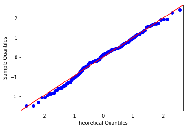

```python
fig = sm.qqplot(result.resid_pearson, stats.norm, fit=True, line='45')
```

#### 3. Shapiro Test

$H_0$ : Standardized residuals are normally distributed.  
$H_1$ : Standardized residuals are not normally distributed

```python
stat, p = stats.shapiro(result.resid_pearson)
print('Statistics=%.3f, p=%.3f' % (stat, p))
```

```
Statistics=0.990, p=0.216
```

The p value is larger than the significant level , we can't reject $H_0$ , that means the normality assumption is satisfied.

### 15. BCG

#### Scatter Plot

```python
#Provide convenient legend.
plt.scatter(df['cases'], df['BCG'])
plt.title('Scatter Plot')
plt.xlabel('BCG')
plt.ylabel('Cases')
plt.show()
```

[output not shown]

#### Regression Model

```python
result = smf.ols('cases ~ BCG', data = df).fit()

# Inspect the results
print(result.summary())
```

```
                            OLS Regression Results
==============================================================================
Dep. Variable:                  cases   R-squared:                       0.001
Model:                            OLS   Adj. R-squared:                 -0.006
Method:                 Least Squares   F-statistic:                    0.1633
Date:                Wed, 03 Jun 2020   Prob (F-statistic):              0.687
Time:                        20:21:31   Log-Likelihood:                -1556.6
No. Observations:                 133   AIC:                             3117.
Df Residuals:                     131   BIC:                             3123.
Df Model:                           1
Covariance Type:            nonrobust
==============================================================================
                 coef    std err          t      P>|t|      [0.025      0.975]
------------------------------------------------------------------------------
Intercept   3227.9593   1.94e+04      0.167      0.868   -3.51e+04    4.15e+04
BCG           85.7711    212.281      0.404      0.687    -334.172     505.714
==============================================================================
Omnibus:                      168.230   Durbin-Watson:                   2.014
Prob(Omnibus):                  0.000   Jarque-Bera (JB):             4895.739
Skew:                           4.859   Prob(JB):                         0.00
Kurtosis:                      31.089   Cond. No.                         690.
==============================================================================

Warnings:
[1] Standard Errors assume that the covariance matrix of the errors is correctly specified.
```

The regression equation is $y = 3227.9593 + 85.7711x$ .

#### Check for normaloty assumption

#### 1. Histogram

```python
_ = plt.hist(result.resid_pearson, bins = 'auto')
```

[output not shown]

#### 2. QQ Plot

```python
fig = sm.qqplot(result.resid_pearson, stats.norm, fit=True, line='45')
```

[output not shown]

#### 3. Shapiro Test

$H_0$ : Standardized residuals are normally distributed.  
$H_1$ : Standardized residuals are not normally distributed

```python
stat, p = stats.shapiro(result.resid_pearson)
print('Statistics=%.3f, p=%.3f' % (stat, p))
```

```
Statistics=0.412, p=0.000
```

The p value is smaller than the significant level , we can reject $H_0$ , that means the normality assumption is not satisfied.

#### Regression Model (Use log value)

```python
#Provide convenient legend.
plt.scatter(df['case_log'], df['BCG'])
plt.title('Scatter Plot')
plt.xlabel('BCG')
plt.ylabel('Cases')
plt.show()
```

[output not shown]

```python
result = smf.ols('case_log ~ BCG', data = df).fit()

# Inspect the results
print(result.summary())
```

```
                            OLS Regression Results
==============================================================================
Dep. Variable:               case_log   R-squared:                       0.000
Model:                            OLS   Adj. R-squared:                 -0.007
Method:                 Least Squares   F-statistic:                   0.06123
Date:                Wed, 03 Jun 2020   Prob (F-statistic):              0.805
Time:                        20:21:31   Log-Likelihood:                -309.78
No. Observations:                 133   AIC:                             623.6
Df Residuals:                     131   BIC:                             629.3
Df Model:                           1
Covariance Type:            nonrobust
==============================================================================
                 coef    std err          t      P>|t|      [0.025      0.975]
------------------------------------------------------------------------------
Intercept      7.3861      1.643      4.496      0.000       4.137      10.636
BCG           -0.0045      0.018     -0.247      0.805      -0.040       0.031
==============================================================================
Omnibus:                        2.055   Durbin-Watson:                   1.482
Prob(Omnibus):                  0.358   Jarque-Bera (JB):                1.766
Skew:                          -0.154   Prob(JB):                        0.414
Kurtosis:                       2.526   Cond. No.                         690.
==============================================================================

Warnings:
[1] Standard Errors assume that the covariance matrix of the errors is correctly specified.
```

#### Check for normaloty assumption

#### 1. Histogram

```python
_ = plt.hist(result.resid_pearson, bins = 'auto')
```

[output not shown]

#### 2. QQ Plot

```python
fig = sm.qqplot(result.resid_pearson, stats.norm, fit=True, line='45')
```

[output not shown]

#### 3. Shapiro Test

$H_0$ : Standardized residuals are normally distributed.  
$H_1$ : Standardized residuals are not normally distributed

```python
stat, p = stats.shapiro(result.resid_pearson)
print('Statistics=%.3f, p=%.3f' % (stat, p))
```

```
Statistics=0.989, p=0.369
```

The p value is larger than the significant level , we can't reject $H_0$ , that means the normality assumption is satisfied.

### HDI

#### Scatter Plot

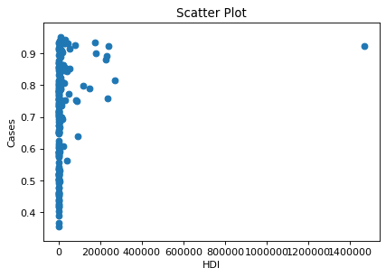

```python
#Provide convenient legend.
plt.scatter(df['cases'], df['HDI'])
plt.title('Scatter Plot')
plt.xlabel('HDI')
plt.ylabel('Cases')
plt.show()
```

#### Regression Model

```python
result = smf.ols('cases ~ HDI', data = df).fit()

# Inspect the results
print(result.summary())
```

```
                            OLS Regression Results
==============================================================================
Dep. Variable:                  cases   R-squared:                       0.044
Model:                            OLS   Adj. R-squared:                  0.038
Method:                 Least Squares   F-statistic:                     8.165
Date:                Sun, 07 Jun 2020   Prob (F-statistic):            0.00478
Time:                        21:50:24   Log-Likelihood:                -2365.1
No. Observations:                 181   AIC:                             4734.
Df Residuals:                     179   BIC:                             4741.
Df Model:                           1
Covariance Type:            nonrobust
==============================================================================
                 coef    std err          t      P>|t|      [0.025      0.975]
------------------------------------------------------------------------------
Intercept  -8.654e+04   4.02e+04     -2.155      0.032   -1.66e+05   -7308.399
HDI         1.574e+05   5.51e+04      2.857      0.005    4.87e+04    2.66e+05
==============================================================================
Omnibus:                      352.675   Durbin-Watson:                   2.093
Prob(Omnibus):                  0.000   Jarque-Bera (JB):           119633.407
Skew:                          10.450   Prob(JB):                         0.00
Kurtosis:                     127.202   Cond. No.                         9.76
==============================================================================

Warnings:
[1] Standard Errors assume that the covariance matrix of the errors is correctly specified.
```

#### Check for normaloty assumption

#### 1. Histogram

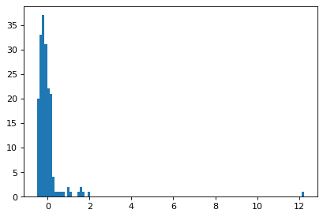

```python
_ = plt.hist(result.resid_pearson, bins = 'auto')
```

#### 2. QQ Plot

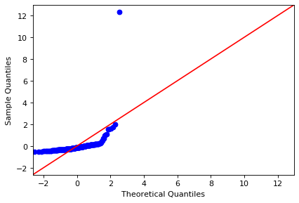

```python
fig = sm.qqplot(result.resid_pearson, stats.norm, fit=True, line='45')
```

#### 3. Shapiro Test

$H_0$ : Standardized residuals are normally distributed.  
$H_1$ : Standardized residuals are not normally distributed

```python
stat, p = stats.shapiro(result.resid_pearson)
print('Statistics=%.3f, p=%.3f' % (stat, p))
```

```
Statistics=0.276, p=0.000
```

The p value is smaller than the significant level , we can reject $H_0$ , that means the normality assumption is not satisfied.

#### Regression Model (Use log value)

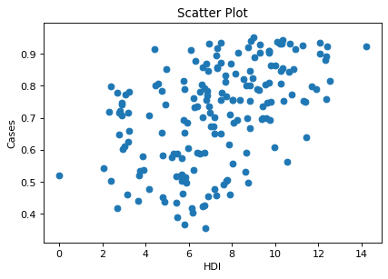

```python
#Provide convenient legend.
plt.scatter(df['case_log'], df['HDI'])
plt.title('Scatter Plot')
plt.xlabel('HDI')
plt.ylabel('Cases')
plt.show()
```

```python
result = smf.ols('case_log ~ HDI', data = df).fit()

# Inspect the results
print(result.summary())
```

```
                            OLS Regression Results
==============================================================================
Dep. Variable:               case_log   R-squared:                       0.225
Model:                            OLS   Adj. R-squared:                  0.221
Method:                 Least Squares   F-statistic:                     52.07
Date:                Sun, 07 Jun 2020   Prob (F-statistic):           1.46e-11
Time:                        21:52:31   Log-Likelihood:                -411.14
No. Observations:                 181   AIC:                             826.3
Df Residuals:                     179   BIC:                             832.7
Df Model:                           1
Covariance Type:            nonrobust
==============================================================================
                 coef    std err          t      P>|t|      [0.025      0.975]
------------------------------------------------------------------------------
Intercept      1.4446      0.823      1.755      0.081      -0.179       3.069
HDI            8.1462      1.129      7.216      0.000       5.919      10.374
==============================================================================
Omnibus:                        3.545   Durbin-Watson:                   1.757
Prob(Omnibus):                  0.170   Jarque-Bera (JB):                3.413
Skew:                          -0.281   Prob(JB):                        0.181
Kurtosis:                       2.630   Cond. No.                         9.76
==============================================================================

Warnings:
[1] Standard Errors assume that the covariance matrix of the errors is correctly specified.
```

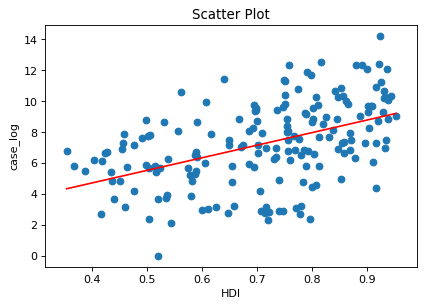

```python
sum1 = df.describe()
plt.scatter(df['HDI'], df['case_log'])
b0 = 1.4446
b1 = 8.1462
X_plot = np.linspace(sum1['HDI']['min'], sum1['HDI']['max'], 100)
Y_plot = b0 + b1 * X_plot
plt.plot(X_plot, Y_plot, color='r')

plt.title('Scatter Plot')
plt.xlabel('HDI')
plt.ylabel('case_log')
plt.savefig('scatter_log_HDI.png')
plt.show()
```

#### Check for normaloty assumption

#### 1. Histogram

```python
_ = plt.hist(result.resid_pearson, bins = 'auto')
```

[output not shown]

#### 2. QQ Plot

```python
fig = sm.qqplot(result.resid_pearson, stats.norm, fit=True, line='45')
```

[output not shown]

#### 3. Shapiro Test

$H_0$ : Standardized residuals are normally distributed.  
$H_1$ : Standardized residuals are not normally distributed

```python
stat, p = stats.shapiro(result.resid_pearson)
print('Statistics=%.3f, p=%.3f' % (stat, p))
```

```
Statistics=0.989, p=0.369
```

The p value is larger than the significant level , we can't reject $H_0$ , that means the normality assumption is satisfied.

### Physicians_per_1000_2009to18

#### Scatter Plot

```python
#Provide convenient legend.
plt.scatter(df['cases'], df['BCG'])
plt.title('Scatter Plot')
plt.xlabel('BCG')
plt.ylabel('Cases')
plt.show()
```

[output not shown]

#### Regression Model

```python
result = smf.ols('cases ~ BCG', data = df).fit()

# Inspect the results
print(result.summary())
```

```
                            OLS Regression Results
==============================================================================
Dep. Variable:                  cases   R-squared:                       0.001
Model:                            OLS   Adj. R-squared:                 -0.006
Method:                 Least Squares   F-statistic:                    0.1633
Date:                Wed, 03 Jun 2020   Prob (F-statistic):              0.687
Time:                        20:21:31   Log-Likelihood:                -1556.6
No. Observations:                 133   AIC:                             3117.
Df Residuals:                     131   BIC:                             3123.
Df Model:                           1
Covariance Type:            nonrobust
==============================================================================
                 coef    std err          t      P>|t|      [0.025      0.975]
------------------------------------------------------------------------------
Intercept   3227.9593   1.94e+04      0.167      0.868   -3.51e+04    4.15e+04
BCG           85.7711    212.281      0.404      0.687    -334.172     505.714
==============================================================================
Omnibus:                      168.230   Durbin-Watson:                   2.014
Prob(Omnibus):                  0.000   Jarque-Bera (JB):             4895.739
Skew:                           4.859   Prob(JB):                         0.00
Kurtosis:                      31.089   Cond. No.                         690.
==============================================================================

Warnings:
[1] Standard Errors assume that the covariance matrix of the errors is correctly specified.
```

The regression equation is $y = 3227.9593 + 85.7711x$ .

#### Check for normaloty assumption

#### 1. Histogram

```python
_ = plt.hist(result.resid_pearson, bins = 'auto')
```

[output not shown]

#### 2. QQ Plot

```python
fig = sm.qqplot(result.resid_pearson, stats.norm, fit=True, line='45')
```

[output not shown]

#### 3. Shapiro Test

$H_0$ : Standardized residuals are normally distributed.  
$H_1$ : Standardized residuals are not normally distributed

```python
stat, p = stats.shapiro(result.resid_pearson)
print('Statistics=%.3f, p=%.3f' % (stat, p))
```

```
Statistics=0.412, p=0.000
```

The p value is smaller than the significant level , we can reject $H_0$ , that means the normality assumption is not satisfied.

#### Regression Model (Use log value)

```python
#Provide convenient legend.
plt.scatter(df['case_log'], df['BCG'])
plt.title('Scatter Plot')
plt.xlabel('BCG')
plt.ylabel('Cases')
plt.show()
```

[output not shown]

```python
result = smf.ols('case_log ~ Physicians_per_1000_2009to18', data = df).fit()

# Inspect the results
print(result.summary())
```

```
                            OLS Regression Results
==============================================================================
Dep. Variable:               case_log   R-squared:                       0.155
Model:                            OLS   Adj. R-squared:                  0.150
Method:                 Least Squares   F-statistic:                     32.01
Date:                Sun, 07 Jun 2020   Prob (F-statistic):           6.14e-08
Time:                        21:56:00   Log-Likelihood:                -410.31
No. Observations:                 177   AIC:                             824.6
Df Residuals:                     175   BIC:                             831.0
Df Model:                           1
Covariance Type:            nonrobust
================================================================================================
                                   coef    std err          t      P>|t|      [0.025      0.975]
------------------------------------------------------------------------------------------------
Intercept                        6.1169      0.279     21.915      0.000       5.566       6.668
Physicians_per_1000_2009to18     0.6640      0.117      5.658      0.000       0.432       0.896
==============================================================================
Omnibus:                        1.905   Durbin-Watson:                   1.491
Prob(Omnibus):                  0.386   Jarque-Bera (JB):                1.637
Skew:                          -0.100   Prob(JB):                        0.441
Kurtosis:                       2.573   Cond. No.                         3.95
==============================================================================

Warnings:
[1] Standard Errors assume that the covariance matrix of the errors is correctly specified.
```

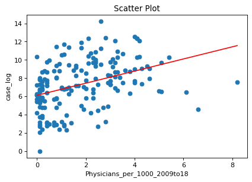

```python
plt.scatter(df['Physicians_per_1000_2009to18'], df['case_log'])
b0 = 6.1169
b1 = 0.6640
X_plot = np.linspace(sum1['Physicians_per_1000_2009to18']['min'], sum1['Physicians_per_1000_2009to18']['max'], 100)
Y_plot = b0 + b1 * X_plot
plt.plot(X_plot, Y_plot, color='r')

plt.title('Scatter Plot')
plt.xlabel('Physicians_per_1000_2009to18')
plt.ylabel('case_log')
plt.savefig('scatter_log_Physicians.png')
plt.show()
```

#### Check for normaloty assumption

#### 1. Histogram

```python
_ = plt.hist(result.resid_pearson, bins = 'auto')
```

[output not shown]

#### 2. QQ Plot

```python
fig = sm.qqplot(result.resid_pearson, stats.norm, fit=True, line='45')
```

[output not shown]

#### 3. Shapiro Test

$H_0$ : Standardized residuals are normally distributed.  
$H_1$ : Standardized residuals are not normally distributed

```python
stat, p = stats.shapiro(result.resid_pearson)
print('Statistics=%.3f, p=%.3f' % (stat, p))
```

```
Statistics=0.989, p=0.369
```

The p value is larger than the significant level , we can't reject $H_0$ , that means the normality assumption is satisfied.

#### Scatter Plot

```python
#Provide convenient legend.
plt.scatter(df['cases'], df['BCG'])
plt.title('Scatter Plot')
plt.xlabel('BCG')
plt.ylabel('Cases')
plt.show()
```

[output not shown]

#### Regression Model

```python
result = smf.ols('cases ~ BCG', data = df).fit()

# Inspect the results
print(result.summary())
```

```
                            OLS Regression Results
==============================================================================
Dep. Variable:                  cases   R-squared:                       0.001
Model:                            OLS   Adj. R-squared:                 -0.006
Method:                 Least Squares   F-statistic:                    0.1633
Date:                Wed, 03 Jun 2020   Prob (F-statistic):              0.687
Time:                        20:21:31   Log-Likelihood:                -1556.6
No. Observations:                 133   AIC:                             3117.
Df Residuals:                     131   BIC:                             3123.
Df Model:                           1
Covariance Type:            nonrobust
==============================================================================
                 coef    std err          t      P>|t|      [0.025      0.975]
------------------------------------------------------------------------------
Intercept   3227.9593   1.94e+04      0.167      0.868   -3.51e+04    4.15e+04
BCG           85.7711    212.281      0.404      0.687    -334.172     505.714
==============================================================================
Omnibus:                      168.230   Durbin-Watson:                   2.014
Prob(Omnibus):                  0.000   Jarque-Bera (JB):             4895.739
Skew:                           4.859   Prob(JB):                         0.00
Kurtosis:                      31.089   Cond. No.                         690.
==============================================================================

Warnings:
[1] Standard Errors assume that the covariance matrix of the errors is correctly specified.
```

The regression equation is $y = 3227.9593 + 85.7711x$ .

#### Check for normaloty assumption

#### 1. Histogram

```python
_ = plt.hist(result.resid_pearson, bins = 'auto')
```

[output not shown]

#### 2. QQ Plot

```python
fig = sm.qqplot(result.resid_pearson, stats.norm, fit=True, line='45')
```

[output not shown]

#### 3. Shapiro Test

$H_0$ : Standardized residuals are normally distributed.  
$H_1$ : Standardized residuals are not normally distributed

```python
stat, p = stats.shapiro(result.resid_pearson)
print('Statistics=%.3f, p=%.3f' % (stat, p))
```

```
Statistics=0.412, p=0.000
```

The p value is smaller than the significant level , we can reject $H_0$ , that means the normality assumption is not satisfied.

#### Regression Model (Use log value)

```python
#Provide convenient legend.
plt.scatter(df['case_log'], df['BCG'])
plt.title('Scatter Plot')
plt.xlabel('BCG')
plt.ylabel('Cases')
plt.show()
```

[output not shown]

```python
result = smf.ols('case_log ~ Specialist_surgical_workforce', data = df).fit()

# Inspect the results
print(result.summary())
```

```
                            OLS Regression Results
==============================================================================
Dep. Variable:               case_log   R-squared:                       0.143
Model:                            OLS   Adj. R-squared:                  0.138
Method:                 Least Squares   F-statistic:                     27.12
Date:                Sun, 07 Jun 2020   Prob (F-statistic):           5.73e-07
Time:                        21:58:11   Log-Likelihood:                -379.40
No. Observations:                 164   AIC:                             762.8
Df Residuals:                     162   BIC:                             769.0
Df Model:                           1
Covariance Type:            nonrobust
=================================================================================================
                                    coef    std err          t      P>|t|      [0.025      0.975]
-------------------------------------------------------------------------------------------------
Intercept                         6.3398      0.264     24.005      0.000       5.818       6.861
Specialist_surgical_workforce     0.0241      0.005      5.208      0.000       0.015       0.033
==============================================================================
Omnibus:                        0.328   Durbin-Watson:                   1.588
Prob(Omnibus):                  0.849   Jarque-Bera (JB):                0.431
Skew:                          -0.099   Prob(JB):                        0.806
Kurtosis:                       2.846   Cond. No.                         78.5
==============================================================================

Warnings:
[1] Standard Errors assume that the covariance matrix of the errors is correctly specified.
```

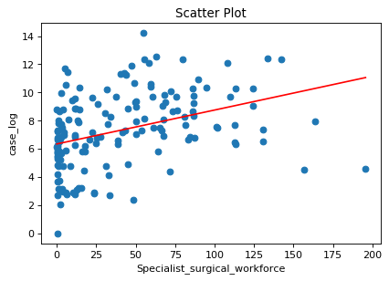

```python
plt.scatter(df['Specialist_surgical_workforce'], df['case_log'])
b0 = 6.3398
b1 = 0.0241
X_plot = np.linspace(sum1['Specialist_surgical_workforce']['min'], sum1['Specialist_surgical_workforce']['max'], 100)
Y_plot = b0 + b1 * X_plot
plt.plot(X_plot, Y_plot, color='r')

plt.title('Scatter Plot')
plt.xlabel('Specialist_surgical_workforce')
plt.ylabel('case_log')
plt.savefig('scatter_log_specialist.png')
plt.show()
```

#### Check for normaloty assumption

#### 1. Histogram

```python
_ = plt.hist(result.resid_pearson, bins = 'auto')
```

[output not shown]

#### 2. QQ Plot

```python
fig = sm.qqplot(result.resid_pearson, stats.norm, fit=True, line='45')
```

[output not shown]

#### 3. Shapiro Test

$H_0$ : Standardized residuals are normally distributed.  
$H_1$ : Standardized residuals are not normally distributed

```python
stat, p = stats.shapiro(result.resid_pearson)
print('Statistics=%.3f, p=%.3f' % (stat, p))
```

```
Statistics=0.989, p=0.369
```

The p value is larger than the significant level , we can't reject $H_0$ , that means the normality assumption is satisfied.